# An illustration of a Bayesian longitudinal design

I usually start with a very simple Bayesian analysis because if something is awry, I’ll notice it faster with a simple example. The code below implements a simple beat-binomial model.

Assume you have a beta prior distribution with alpha=4 and beta=16. You collect 60 observations and observe 18 successes and 42 failures.

You don’t really need jags for this. The posterior distribution is beta with alpha=4+18=22 and beta=16+42=58. The posterior mean is 0.275 and the posterior standard deviation is 0.05.

```r
library("rjags")
fnm <- "jags_beta_binomial.txt"
mon <- c("pi")
out <- list(description="jags output")
dat <- list(a=4, b=16, x=18, n=60)
mod <- jags.model(fnm, data=dat, quiet=TRUE)
out$bb1 <-
  coda.samples(mod, variable.names=mon, n.iter=1000, by=1000, progress.bar=NULL)
summary(out$bb1)
```

```
Iterations = 1:1000
Thinning interval = 1
Number of chains = 1
Sample size per chain = 1000

1. Empirical mean and standard deviation for each variable,
   plus standard error of the mean:

          Mean             SD       Naive SE Time-series SE
      0.275455       0.049226       0.001557       0.001557

2. Quantiles for each variable:

  2.5%    25%    50%    75%  97.5%
0.1825 0.2409 0.2751 0.3076 0.3760
```

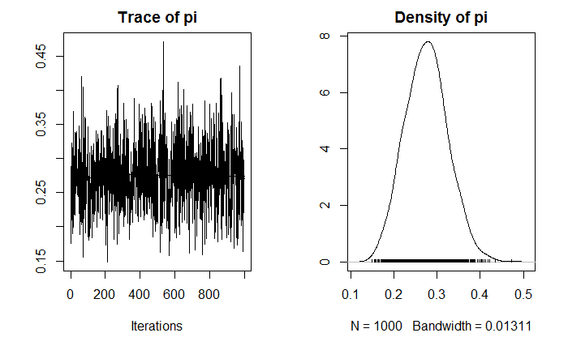

```r
plot(out$bb1)
```

Now, try to run one of the examples in the BUGS manuals that is reasonably close to your problem. For our problem, the very first example in volume 1 works well.

http://www.openbugs.net/Examples/Rats.html

I had to fix two things to get this example to run properly in jags. First, I had to remove some lines of code that used functions like post.p.value. Second, I have to transpose the matrix of data. But with these changes it ran just fine.

```r
dat <- list(x = c(8.0, 15.0, 22.0, 29.0, 36.0), xbar = 22, N = 30, T = 5,
      Y = structure(
         .Data = c(151, 199, 246, 283, 320,
                     145, 199, 249, 293, 354,
                     147, 214, 263, 312, 328,
                     155, 200, 237, 272, 297,
                     135, 188, 230, 280, 323,
                     159, 210, 252, 298, 331,
                     141, 189, 231, 275, 305,
                     159, 201, 248, 297, 338,
                     177, 236, 285, 350, 376,
                     134, 182, 220, 260, 296,
                     160, 208, 261, 313, 352,
                     143, 188, 220, 273, 314,
                     154, 200, 244, 289, 325,
                     171, 221, 270, 326, 358,
                     163, 216, 242, 281, 312,
                     160, 207, 248, 288, 324,
                     142, 187, 234, 280, 316,
                     156, 203, 243, 283, 317,
                     157, 212, 259, 307, 336,
                     152, 203, 246, 286, 321,
                     154, 205, 253, 298, 334,
                     139, 190, 225, 267, 302,
                     146, 191, 229, 272, 302,
                     157, 211, 250, 285, 323,
                     132, 185, 237, 286, 331,
                     160, 207, 257, 303, 345,
                     169, 216, 261, 295, 333,
                     157, 205, 248, 289, 316,
                     137, 180, 219, 258, 291,
                     153, 200, 244, 286, 324),
                  .Dim = c(5,30)))
dat$Y <- t(dat$Y)
init <- list(alpha = c(250, 250, 250, 250, 250, 250, 250, 250, 250, 250, 250, 250, 250, 250, 250,
                  250, 250, 250, 250, 250, 250, 250, 250, 250, 250, 250, 250, 250, 250, 250),
      beta = c(6, 6, 6, 6, 6, 6, 6, 6, 6, 6, 6, 6, 6, 6, 6,
                  6, 6, 6, 6, 6, 6, 6, 6, 6, 6, 6, 6, 6, 6, 6),
      alpha.c = 150, beta.c = 10,
      tau.c = 1, alpha.tau = 1, beta.tau = 1)
print(dat)
```

```
$x
[1]  8 15 22 29 36

$xbar
[1] 22

$N
[1] 30

$T
[1] 5

$Y
      [,1] [,2] [,3] [,4] [,5]
 [1,]  151  199  246  283  320
```

[output cut: 29 more lines]

```r
print(init)
```

```
$alpha
 [1] 250 250 250 250 250 250 250 250 250 250 250 250 250 250 250 250 250 250 250 250 250
[22] 250 250 250 250 250 250 250 250 250

$beta
 [1] 6 6 6 6 6 6 6 6 6 6 6 6 6 6 6 6 6 6 6 6 6 6 6 6 6 6 6 6 6 6

$alpha.c
[1] 150

$beta.c
[1] 10

$tau.c
[1] 1

$alpha.tau
[1] 1

$beta.tau
[1] 1
```

```r
fnm <- "jags_rats.txt"
mon <- c("alpha0", "beta.c", "sigma")
mod <- jags.model(fnm, dat, init, quiet=TRUE)
out$rats <-
  coda.samples(mod, variable.names=mon, n.iter=1000, by=1000, progress.bar=NULL)
summary(out$rats)
```

```
Iterations = 1:1000
Thinning interval = 1
Number of chains = 1
Sample size per chain = 1000

1. Empirical mean and standard deviation for each variable,
   plus standard error of the mean:

          Mean     SD Naive SE Time-series SE
alpha0 106.415 3.6769 0.116272       0.129964
beta.c   6.188 0.1070 0.003384       0.004344
sigma    6.141 0.6375 0.020161       0.033899

2. Quantiles for each variable:

         2.5%     25%     50%     75%   97.5%
alpha0 98.812 104.196 106.460 108.629 113.546
beta.c  5.981   6.114   6.187   6.260   6.390
sigma   5.294   5.785   6.074   6.419   7.173
```

Now let’s see if we can modify this example to fit our particular setting.

Our longitudinal setting has two measurements: pre and post. So strip the last three columns from the matrix Y. There is one within subject factor, time, which is represents by X1. There is a between subjects factor, treatment group, which is represented by X2.

```r
dat <- list(X1 = c(0, 1), X2 = rep(0:1, c(20, 10)), N = 30, T = 2,
      Y = structure(
         .Data = c(151, 199,
                     145, 199,
                     147, 214,
                     155, 200,
                     135, 188,
                     159, 210,
                     141, 189,
                     159, 201,
                     177, 236,
                     134, 182,
                     160, 208,
                     143, 188,
                     154, 200,
                     171, 221,
                     163, 216,
                     160, 207,
                     142, 187,
                     156, 203,
                     157, 212,
                     152, 203,
                     154, 205,
                     139, 190,
                     146, 191,
                     157, 211,
                     132, 185,
                     160, 207,
                     169, 216,
                     157, 205,
                     137, 180,
                     153, 200),
                  .Dim = c(2,30)))

dat$Y <- t(dat$Y)
init <- list(alpha = rep(150, 30),
      beta1 = 50, beta2 = 20, beta3 = 5,
      alpha.c = 150,
      tau.c = 1, alpha.tau = 1)

print(dat)
print(init)

fnm <- "jags_lon1.txt"
mon <- c("alpha.c", "beta1", "beta2", "beta3")

mod <- jags.model(fnm, dat, init, quiet=TRUE)
out$lon1 <-
  coda.samples(mod, variable.names=mon, n.iter=1000, by=1000, progress.bar=NULL)
summary(out$lon1)
```

[output not shown]

Okay, so far, so good. The research hypothesis, related to a non-inferiority question, is that the probability that the treatment group is not more than 2.5 units worse than the control has to be at least 80%. There are several ways to approach this, but one simple way is just to count the number of times that beta3 is less than or equal to 2.5.

```r
sum(unlist(out$lon1[ ,4])<=2.5)
```

[output not shown]